# STA Climate Change – Biannual Traffic Surveys

# Daily Patterns – Walking

### Typical Daily Count across Locations – Walking

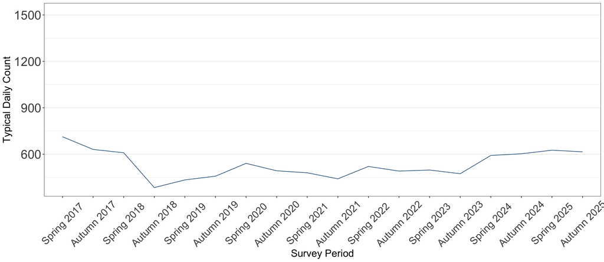

### Daily Average Count per Location – Walking

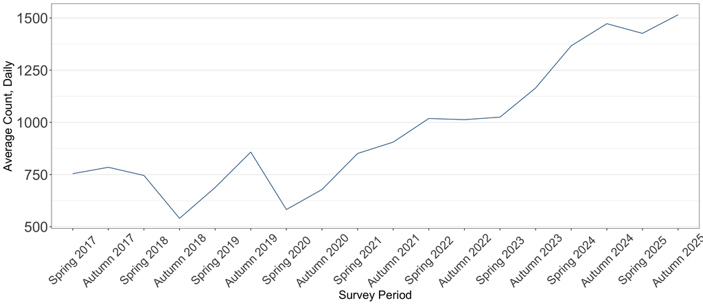

### Total Count – Walking

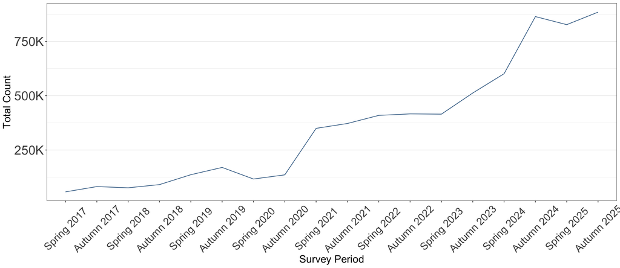

### No. of Locations – Walking

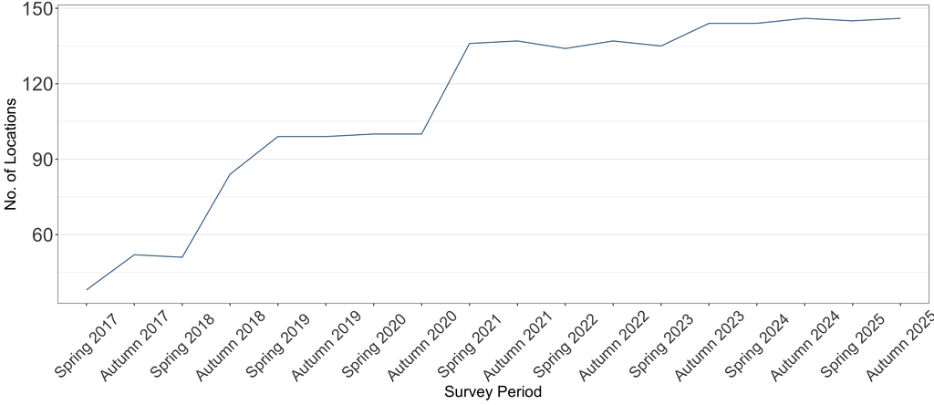

# Change over Time – Active Travel

### Change over Time

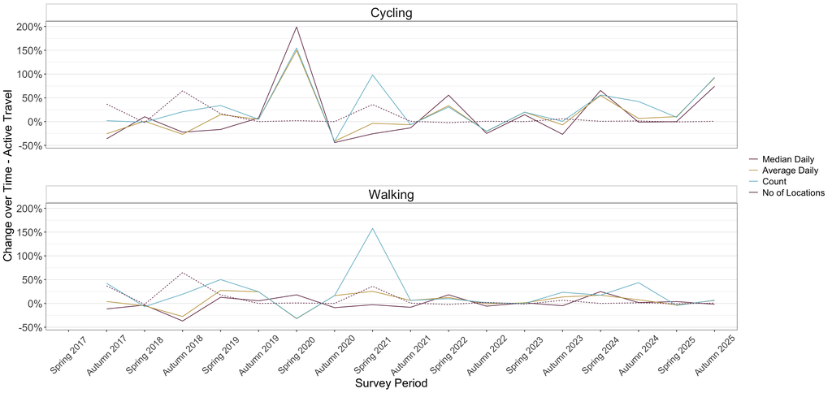

### Change by Season

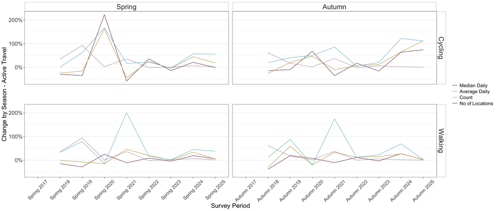

# Hourly Patterns – Active Travel

### Cycling – per Biannual Period

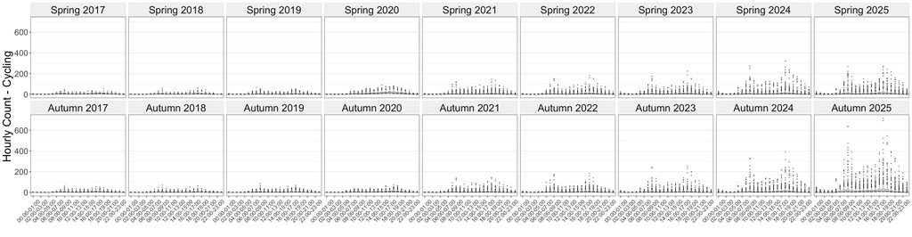

### Walking – per Biannual Period

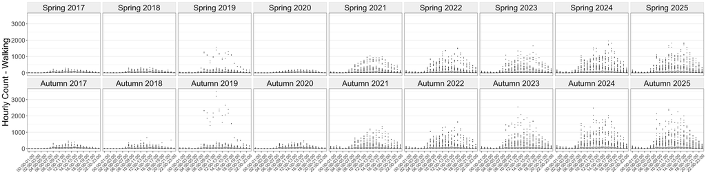

# About

The biannual survey is carried out by Scotland's National Monitoring Framework, on a Wednesday and the following Thursday normally toward the end of May and September. It tracks, on selected roads in settlements (or locations) for each of the 32 local authorities, nine modes of transport, including (passenger) cars and the two main modes of active travel – walking and cycling.

Where a survey cannot be carried out on the survey dates data is typically collected on the same weekdays the following week. In a few instances there is a delay of several weeks; while this may introduce seasonality differences especially for active travel, to allow comparison over time for each location, delayed counts are included in the analysis.

#### Data Sources

Data feeding into the analysis presented may be accessed via Cycling Scotland's [Active Travel Open Data Portal](https://usmart.io/org/cyclingscotland/discovery/discovery-view-detail/b9fdd462-1f45-4252-aedc-fbc596abcd90).

### Settlements with surveys completed designated survey month, cf. those partially or fully delayed per period

Survey Period

Survey Months

No of Settlements

Surveyed on Date

Delayed Survey

Early Survey

Spring 2017

May

9

9

Autumn 2017

Sep

19

19

Spring 2018

May

19

19

Autumn 2018

Sep

30

30

Spring 2019

May

32

32

Autumn 2019

Sep, Oct

32

32

1

Spring 2020

May, Jul

33

32

2

Autumn 2020

Sep

33

33

Spring 2021

May, Jun

75

75

3

Autumn 2021

Sep, Oct

75

73

3

Spring 2022

May, Jun

74

71

6

Autumn 2022

Aug, Sep, Oct

75

73

2

1

Spring 2023

May, Jun

75

73

3

Autumn 2023

Sep, Oct, Jan

76

71

9

Spring 2024

May

74

74

Autumn 2024

Sep, Oct

76

74

2

Spring 2025

May, Jun

72

71

4

Autumn 2025

Sep, Oct

72

69

7